# Week2b

```python
import pandas as pd
import seaborn as sns
from scipy.stats import chi2_contingency
```

### Portfolio assignment 11

20 min: Do a Numerical VS Categorical bivariate analysis on the penguins dataset.

- Choose one of the categorical columns: species, island or sex
- use .groupby('').mean() too look at the means of the numerical columns. Does it look like there is a difference between categories?
- Use the seaborn barplot to plot the mean and confidence. Create this plot for each of the numerical columns (bill_length_mm bill_depth_mm, flipper_length_mm, body_mass_g)
- For each of the plots, write a conclusion: Is there a statistically significant difference for this numerical column for each category?
- Optional: Repeat this proces for the other two categorical columns

```python
penguins = sns.load_dataset("penguins")
```

```python
penguins.head()
```

|  | species | island | bill_length_mm | bill_depth_mm | flipper_length_mm | body_mass_g | sex |
| --- | --- | --- | --- | --- | --- | --- | --- |
| 0 | Adelie | Torgersen | 39.1 | 18.7 | 181.0 | 3750.0 | Male |
| 1 | Adelie | Torgersen | 39.5 | 17.4 | 186.0 | 3800.0 | Female |
| 2 | Adelie | Torgersen | 40.3 | 18.0 | 195.0 | 3250.0 | Female |
| 3 | Adelie | Torgersen | NaN | NaN | NaN | NaN | NaN |
| 4 | Adelie | Torgersen | 36.7 | 19.3 | 193.0 | 3450.0 | Female |

```python
penguins.groupby('sex').mean()
```

| sex | bill_length_mm | bill_depth_mm | flipper_length_mm | body_mass_g |
| --- | --- | --- | --- | --- |
| Female | 42.096970 | 16.425455 | 197.363636 | 3862.272727 |
| Male | 45.854762 | 17.891071 | 204.505952 | 4545.684524 |

#### Bill_length_mm

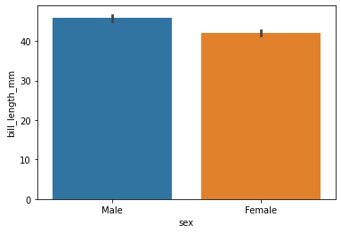

```python
sns.barplot(y="bill_length_mm", x="sex", data=penguins)
```

##### Conclusie

Der is niet een enorm verschil tussen de twee geslachten er kan met wat zekerheid gezegd worden dat de bill length bij mannen hoger is.

#### Bill_depth_mm

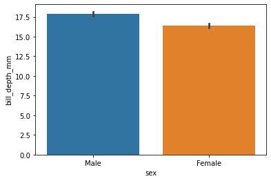

```python
sns.barplot(y="bill_depth_mm", x="sex", data=penguins)
```

##### Conclusie

Der is niet een enorm verschil tussen de twee geslachten er kan met wat zekerheid gezegd worden dat de bill depth bij mannen hoger is.

#### Flipper_length_mm

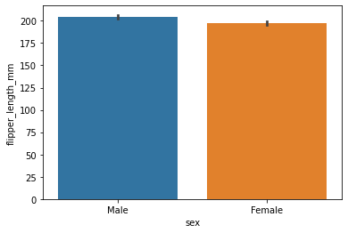

```python
sns.barplot(y="flipper_length_mm", x="sex", data=penguins)
```

#### Body_mass_g

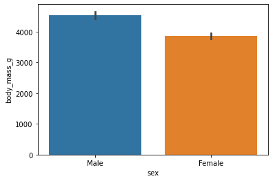

```python
sns.barplot(y="body_mass_g", x="sex", data=penguins)
```

##### Conclusie

Hier is een duidelijk verschil tussen de geslachten te zien. De mannen steken redelijk ver boven de vrouwen uit.

### Portfolio assignment 12

30 min: Perform a bivariate analysis on at least 3 combinations of a numerical column with a categorical column in the dataset that you chose in portfolio assignment 4. Use *.groupby('columnname').mean()* to calculate the means. Is there a difference between categories? Then use seaborn barplots to check if there is a statistically significant difference.

```python
lecDataset = pd.read_csv('Datasets/lec_playerdata.csv', sep=',')
lecDataset.head()
```

|  | Unnamed: 0 | Player | Team | Pos | GP | W% | K | D | A | KDA | ... | CSD10 | CSPM | CS%P15 | DPM | DMG% | EGPM | Gold% | WPM | WCPM | Split |
| --- | --- | --- | --- | --- | --- | --- | --- | --- | --- | --- | --- | --- | --- | --- | --- | --- | --- | --- | --- | --- | --- |
| 0 | 0 | Abbedagge | Schalke 04 | Middle | 19.0 | 47.0 | 41.0 | 43.0 | 79.0 | 2.8 | ... | -3.3 | 9.0 | 26.6 | 417.0 | 24.6 | 257.9 | 22.5 | 0.51 | 0.19 | Spring Regular |
| 1 | 1 | Alphari | Origen | Top | 18.0 | 67.0 | 29.0 | 30.0 | 73.0 | 3.4 | ... | 1.7 | 8.0 | 22.4 | 354.0 | 21.8 | 243.5 | 20.9 | 0.54 | 0.15 | Spring Regular |
| 2 | 2 | Attila | Vitality | ADC | 18.0 | 56.0 | 48.0 | 30.0 | 77.0 | 4.2 | ... | -3.9 | 10.2 | 33.4 | 458.0 | 25.6 | 316.7 | 26.9 | 0.35 | 0.39 | Spring Regular |
| 3 | 3 | Broxah | Fnatic | Jungle | 18.0 | 61.0 | 49.0 | 27.0 | 93.0 | 5.3 | ... | -1.8 | 5.0 | 13.2 | 255.0 | 14.9 | 200.1 | 17.1 | 0.36 | 0.34 | Spring Regular |
| 4 | 4 | Bwipo | Fnatic | Top | 18.0 | 61.0 | 41.0 | 42.0 | 80.0 | 2.9 | ... | -10.0 | 7.6 | 23.6 | 444.0 | 25.5 | 239.7 | 20.4 | 0.48 | 0.16 | Spring Regular |

5 rows × 25 columns

#### Team

```python
lecDataset.groupby('Team').mean()
```

| Team | Unnamed: 0 | GP | W% | K | D | A | KDA | KP | DTH% | FB% | ... | XPD10 | CSD10 | CSPM | CS%P15 | DPM | DMG% | EGPM | Gold% | WPM | WCPM |
| --- | --- | --- | --- | --- | --- | --- | --- | --- | --- | --- | --- | --- | --- | --- | --- | --- | --- | --- | --- | --- | --- |
| Excel Esports | 89.800000 | 9.000000 | 17.350000 | 18.050000 | 25.350000 | 39.400000 | 2.035000 | 61.085000 | 19.670000 | 10.200000 | ... | -196.950000 | -6.555000 | 5.775000 | 19.680000 | 356.150000 | 19.950000 | 211.605000 | 19.825000 | 0.691500 | 0.224000 |
| Fnatic | 123.062500 | 9.843750 | 72.937500 | 29.625000 | 25.031250 | 63.750000 | 5.862500 | 61.800000 | 18.478125 | 23.718750 | ... | 21.562500 | -1.571875 | 6.546875 | 20.375000 | 396.031250 | 20.428125 | 260.709375 | 20.259375 | 0.630000 | 0.253750 |
| G2 Esports | 105.533333 | 8.666667 | 76.400000 | 32.266667 | 20.900000 | 64.633333 | 5.760000 | 60.276667 | 19.943333 | 28.066667 | ... | 13.300000 | 0.993333 | 6.106667 | 19.266667 | 448.533333 | 19.136667 | 263.426667 | 19.560000 | 0.709000 | 0.274000 |
| Misfits | 93.000000 | 11.250000 | 34.375000 | 24.312500 | 32.250000 | 50.312500 | 2.393750 | 62.718750 | 20.025000 | 23.375000 | ... | -56.000000 | 0.568750 | 6.193750 | 19.006250 | 313.375000 | 19.037500 | 212.762500 | 19.243750 | 0.706875 | 0.256875 |
| Origen | 111.750000 | 12.750000 | 44.000000 | 28.650000 | 29.950000 | 61.750000 | 3.235000 | 64.515000 | 20.010000 | 22.000000 | ... | 47.700000 | 1.230000 | 6.460000 | 20.000000 | 340.450000 | 19.995000 | 220.965000 | 20.000000 | 0.677000 | 0.282000 |
| Rogue | 113.631579 | 11.315789 | 35.368421 | 24.842105 | 30.052632 | 54.526316 | 3.100000 | 63.636842 | 19.700000 | 18.684211 | ... | -48.263158 | -1.389474 | 6.289474 | 20.121053 | 327.473684 | 19.936842 | 211.278947 | 19.863158 | 0.679474 | 0.233158 |
| SK Gaming | 85.187500 | 13.125000 | 38.750000 | 30.062500 | 36.312500 | 70.500000 | 2.781250 | 66.562500 | 20.250000 | 21.187500 | ... | -40.312500 | -0.681250 | 6.612500 | 20.325000 | 366.937500 | 20.312500 | 223.700000 | 20.231250 | 0.643750 | 0.287500 |
| Schalke 04 | 140.700000 | 12.750000 | 40.750000 | 34.200000 | 29.400000 | 75.700000 | 3.790000 | 63.085000 | 19.990000 | 25.900000 | ... | -98.800000 | -2.635000 | 6.380000 | 20.005000 | 351.900000 | 19.995000 | 223.800000 | 20.000000 | 0.683000 | 0.283000 |
| Splyce | 129.692308 | 11.153846 | 48.576923 | 30.423077 | 28.461538 | 68.807692 | 3.442308 | 63.507692 | 20.196154 | 29.076923 | ... | 22.653846 | 1.250000 | 6.819231 | 20.315385 | 365.038462 | 20.026923 | 234.319231 | 20.100000 | 0.672308 | 0.286923 |
| Vitality | 89.954545 | 10.000000 | 34.636364 | 22.772727 | 29.454545 | 47.954545 | 2.527273 | 60.577273 | 20.081818 | 18.181818 | ... | 28.090909 | 1.672727 | 6.609091 | 20.622727 | 365.954545 | 20.654545 | 226.704545 | 20.354545 | 0.664091 | 0.237273 |

10 rows × 21 columns

##### Teams with W% (Win percentage)

[output not shown]

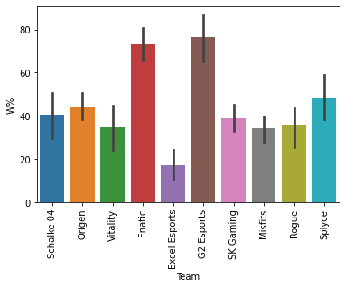

```python
g = sns.barplot(y="W%", x="Team", data=lecDataset)
g.set_xticklabels(g.get_xticklabels(), rotation=90)
```

[output not shown]

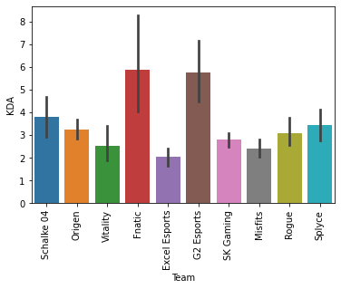

```python
g = sns.barplot(y="KDA", x="Team", data=lecDataset)
g.set_xticklabels(g.get_xticklabels(), rotation=90)
```

[output not shown]

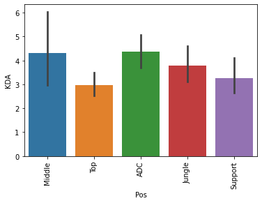

```python
g = sns.barplot(y="KDA", x="Pos", data=lecDataset)
g.set_xticklabels(g.get_xticklabels(), rotation=90)
```

### Portfolio assignment 13

10 min: Do a bivariate analysis on the penguins dataset for the following combination of columns:

- species VS sex
- island VS sex

For this bivariate analysis, at least perform the following tasks:

- Do you expect their to be a correlation between the two columns?
- Create a contigency table. Do you observe different ratios between categories here?
- Create a bar plot for this contigency table. Do you observe different ratios between categories here?
- Do a chi-squared test. What does the result say? What's the chance of there being a correlation between the two columns?

#### Species VS sex

##### Do you expect their to be a correlation between the two columns?

Ik denk het zelf niet. Ik denk niet dat het ene geslacht afhankelijk echt meer aanwezig is dan het andere geslacht per soort.

##### Contigency Table

```python
contingencyTable = penguins.groupby(['species','sex']).size().unstack('species', fill_value=0)
contingencyTable
```

| species sex | Adelie | Chinstrap | Gentoo |
| --- | --- | --- | --- |
| Female | 73 | 34 | 58 |
| Male | 73 | 34 | 61 |

##### Bar Plot

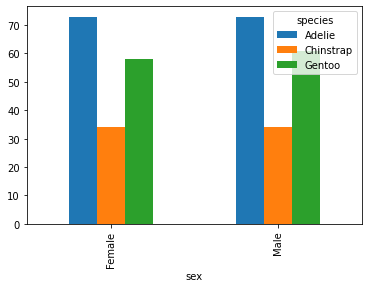

```python
contingencyTable.plot(kind='bar')
```

##### Chi-squared test

```python
chi2_contingency(contingencyTable)
```

```
(0.04860717014078319,
 0.9759893689765846,
 2,
 array([[72.34234234, 33.69369369, 58.96396396],
        [73.65765766, 34.30630631, 60.03603604]]))
```

Volgens de Chi_squared test zit er geen verband in de species en gender.

#### Island vs sex

##### Do you expect their to be a correlation between the two columns?

Ik verwacht denk ik geen verband. Ik denk dat het op elk eiland wel anders is met hoe groot de bevolking is.

##### Contigency Table

```python
contingencyTableTwo = penguins.groupby(['island','sex']).size().unstack('island', fill_value=0)
contingencyTableTwo
```

| island sex | Biscoe | Dream | Torgersen |
| --- | --- | --- | --- |
| Female | 80 | 61 | 24 |
| Male | 83 | 62 | 23 |

##### Bar Plot

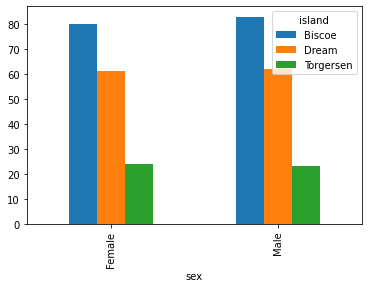

```python
contingencyTableTwo.plot(kind='bar')
```

##### Chi-squared test

```python
chi2_contingency(contingencyTableTwo)
```

```
(0.05759904881286206,
 0.971611229281065,
 2,
 array([[80.76576577, 60.94594595, 23.28828829],
        [82.23423423, 62.05405405, 23.71171171]]))
```

Volgens de Chi_squared test zit er geen verband in de island en gender.

### Portfolio assignment 14

Perform a bivariate analysis on at least 1 combination of 2 columns with categorical data in the dataset that you chose in portfolio assignment 4.

Do you expect their to be a correlation between the two columns? Create a contigency table. Do you observe different ratios between categories here? Create a bar plot for this contigency table. Do you observe different ratios between categories here? Do a chi-squared test. What does the result say? What's the chance of there being a correlation between the two columns?

#### Team vs Position

##### Contigency Table

```python
contingencyTableThree= lecDataset.groupby(['Team','Pos']).size().unstack('Team', fill_value=0)
contingencyTableThree
```

| Team Pos | Excel Esports | Fnatic | G2 Esports | Misfits | Origen | Rogue | SK Gaming | Schalke 04 | Splyce | Vitality |
| --- | --- | --- | --- | --- | --- | --- | --- | --- | --- | --- |
| ADC | 4 | 7 | 6 | 3 | 4 | 4 | 3 | 4 | 5 | 4 |
| Jungle | 3 | 5 | 5 | 3 | 4 | 3 | 3 | 4 | 5 | 4 |
| Middle | 5 | 8 | 7 | 3 | 4 | 3 | 4 | 4 | 5 | 6 |
| Support | 5 | 6 | 7 | 4 | 4 | 4 | 3 | 4 | 5 | 4 |
| Top | 3 | 6 | 5 | 3 | 4 | 5 | 3 | 4 | 6 | 4 |

##### Bar Plot

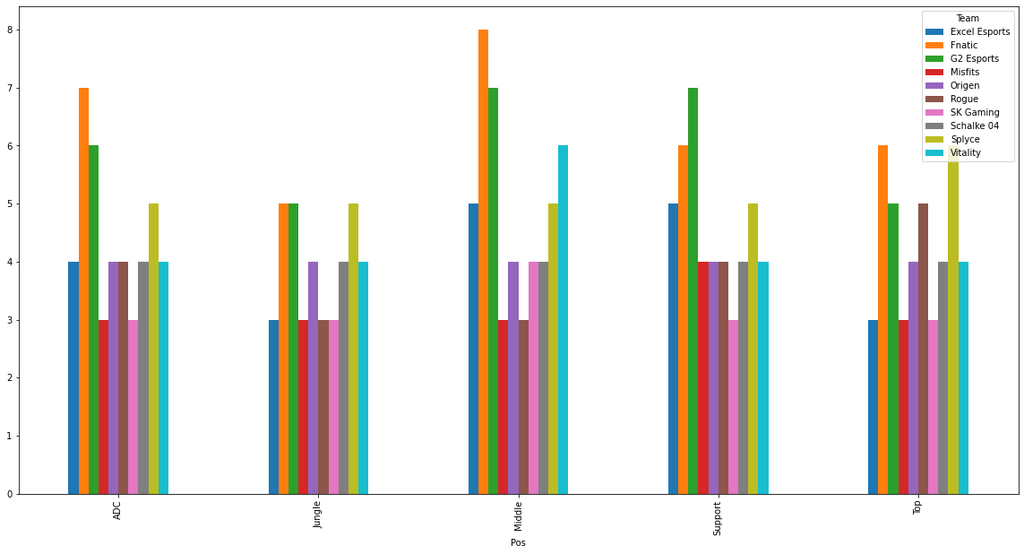

```python
tableThree = contingencyTableThree.plot(kind='bar', figsize = (20, 10))
```

##### Chi-squared test

```python
chi2_contingency(contingencyTableThree)
```

```
(3.2826796001528584,
 0.9999999999997525,
 36,
 array([[3.98190045, 6.37104072, 5.97285068, 3.18552036, 3.98190045,
         3.78280543, 3.18552036, 3.98190045, 5.17647059, 4.3800905 ],
        [3.52941176, 5.64705882, 5.29411765, 2.82352941, 3.52941176,
         3.35294118, 2.82352941, 3.52941176, 4.58823529, 3.88235294],
        [4.43438914, 7.09502262, 6.65158371, 3.54751131, 4.43438914,
         4.21266968, 3.54751131, 4.43438914, 5.76470588, 4.87782805],
        [4.16289593, 6.66063348, 6.24434389, 3.33031674, 4.16289593,
         3.95475113, 3.33031674, 4.16289593, 5.41176471, 4.57918552],
        [3.89140271, 6.22624434, 5.83710407, 3.11312217, 3.89140271,
         3.69683258, 3.11312217, 3.89140271, 5.05882353, 4.28054299]]))
```

Der is hier totáál geen verband!